# H1-B Visa Petitions for Data Science Positions in 2015

Sharan Naribole

Contributed by Sharan Naribole. He is currently undertaking the part-time online bootcamp organized by NYC Data Science Academy (Dec 2016- April 2017). This blog is based on his bootcamp project - R Exploratory Data Analysis

## Abstract

The H-1B is an employment-based, non-immigrant visa category for temporary foreign workers in the United States. Every year, the US immigration department accepts over 200,000 petitions and selects 85,000 applications through a random process. The application data is available for public access to perform in-depth longitudinal research and analysis. This data provides key insights into the prevailing wages for job titles being sponsored by US employers under H1-B visa category. In particular, I utilize the 2011-2015 H-1B petition disclosure data to analyze the Salary distribution across different industries, states and seniority levels for Data Science positions.

```r
library(dplyr)
library(ggplot2)
library(readxl)
library(ggthemes)
library(RColorBrewer)
```

## H-1B Visa Data Introduction

The H-1B is an employment-based, non-immigrant visa category for temporary foreign workers in the United States. For a foreign national to apply for H1-B visa, an US employer must offer a job and petition for H-1B visa with the US immigration department. This is the most common visa status applied for and held by international students once they complete college/ higher education (Masters, PhD) and work in a full-time position.

The Office of Foreign Labor Certification (OFLC) generates program data that is useful information about the immigration programs including the H1-B visa. The disclosure data updated annually is available at https://www.foreignlaborcert.doleta.gov/performancedata.cfm

This is a huge dataset over 2.5 million rows of H-1B petitions.

## Data Cleaning and Transformation

```r
## Function to transform wage to annual scale
pw_unit_to_yearly = function(prevailing_wage, pw_unit_of_pay) {
  return(ifelse(pw_unit_of_pay == "Year", prevailing_wage, ifelse(pw_unit_of_pay == "Hour", 2080*prevailing_wage, ifelse(pw_unit_of_pay== "Week", 52*prevailing_wage, ifelse(pw_unit_of_pay == "Month", 12*prevailing_wage, 26*prevailing_wage)))))
}
```

```r
split_city = function(city) {
  return(strsplit(city,split=",")[1])
}
```

The main data transformation of raw data of a given year: 1. Mutating Year 2. Column matching 3. Filtering rows with H1-B visa and Full Time Employment 4. Converting Prevailing Wage to Year Scale 5. Filtering columns relevant to data analysis

```r
data_transform = function(raw_data_path,h1b_df, year) {

  new_df = read_excel(raw_data_path)

  # Changing column names of data before 2015 to match with 2015 column names
  print("Column matching ..")
  if(year != 2015){

    new_df = new_df %>%
             select(-LCA_CASE_EMPLOYER_POSTAL_CODE)
    new_df = new_df %>%
             rename(CASE_NUMBER = LCA_CASE_NUMBER,
                    CASE_STATUS = STATUS,
                    EMPLOYER_NAME = LCA_CASE_EMPLOYER_NAME,
                    SOC_NAME = LCA_CASE_SOC_NAME,
                    JOB_TITLE = LCA_CASE_JOB_TITLE,
                    FULL_TIME_POSITION = FULL_TIME_POS,
                    PREVAILING_WAGE = PW_1,
                    PW_UNIT_OF_PAY = PW_UNIT_1,
                    WORKSITE_CITY = LCA_CASE_WORKLOC1_CITY,
                    WORKSITE_STATE = LCA_CASE_WORKLOC1_STATE)
  }

  # Adding Year column to dataframe and removing state from City column if exists
  print("Mutating year ..")
  new_df = new_df %>%
           mutate(YEAR = as.character(year))

  ## Filtering rows with H1-B visa and Full Time Employment
  print("Filtering H1-B visas with Full-time employment ..")
  new_df = new_df %>%
           filter(VISA_CLASS == "H-1B" & FULL_TIME_POSITION == 'Y')

  ## Removing rows with PW_UNIT_OF_PAY not mentioned, will come back to this later
  new_df = new_df %>%
           filter(!is.na(PW_UNIT_OF_PAY))

  ## Converting to numeric form text
  new_df = new_df %>%
           mutate(PREVAILING_WAGE = as.numeric(PREVAILING_WAGE))

  # Converting wage to year scale
  print("Converting Prevailing wage to Year scale")
  new_df = new_df %>%
           mutate(PREVAILING_WAGE =  pw_unit_to_yearly(PREVAILING_WAGE, PW_UNIT_OF_PAY))

  ## Retaining only the relevant columns for the data analysis
  print("Filtering relevant columns ..")
  new_df = new_df %>%
           select(CASE_NUMBER,
                  CASE_STATUS,
                  EMPLOYER_NAME,
                  SOC_NAME,
                  JOB_TITLE,
                  PREVAILING_WAGE,
                  WORKSITE_CITY,
                  WORKSITE_STATE,
                  YEAR)

  # Merging data with already transformed data
  print("Merging data ..")
  new_df = rbind(h1b_df, new_df)

  print(paste("Transformed and merged", year, "H-1B data"))

  return(new_df)
}
```

Next, I call the above function for the multiple sources of data.

```r
#Empty data frame
h1b_df = data.frame()

for(year in seq(2015,2011)) {
  path = paste0("data/",year,"_raw_data.xlsx")
  h1b_df = data_transform(path, h1b_df, year)
}
```

```
## [1] "Column matching .."
## [1] "Mutating year .."
## [1] "Filtering H1-B visas with Full-time employment .."
## [1] "Converting Prevailing wage to Year scale"
## [1] "Filtering relevant columns .."
## [1] "Merging data .."
## [1] "Transformed and merged 2015 H-1B data"
## [1] "Column matching .."
## [1] "Mutating year .."
## [1] "Filtering H1-B visas with Full-time employment .."
## [1] "Converting Prevailing wage to Year scale"
## [1] "Filtering relevant columns .."
## [1] "Merging data .."
## [1] "Transformed and merged 2014 H-1B data"
## [1] "Column matching .."
```

[output cut: 20 more lines]

The useful columns for our data analysis include:

1)**EMPLOYER_NAME**: Name of employer submitting the H1-B application.

2)**JOB_TITLE**: Title of the job using which we can filter the Data Science positions and the Seniority Level

3)**SOC_NAME**: The broad area/industry associated with a job as classified by the Standard Occupational (SOC) System. This gives us insight into the fields in which Data Scientist positions are being offered.

4)**PREVAILING_WAGE**: The prevailing wage for a job position is defined as the average wage paid to similarly employed workers in the requested occupation in the area of intended employment. The prevailing wage is based on the employer’s minimum requirements for the position. ( Source: https://www.usavisanow.com/h-1b-visa/h1b-visa-resources/prevailing-wage/). This column will be our key metric in the data analysis.

5)**WORKSITE_CITY, WORKSITE_STATE**: The foreign worker’s intended area of employment. We will explore the relationship between prevailing wage for Data Scientist position across different locations.

I focus on the annual prevailing wage for full-time positions. Consequently, the rows confirming full_time positions are filtered.

There was some error in the Employer’s Address column in older data but I won’t be using that column for my analysis. Anyways, it is filtered out in my data

Last transformation step is to classify Jobs based on the Titles and the Seniority of the Job. This is because seniority results in a higher wage. For example, a Senior/ Lead Data Scientist is expected to earn more than a regular Data Scientist. I will use the JOB_TITLE column to extract this information.

JOB_LEVEL: 1. Basic: if there are no titles 2. Lead: if Senior/ Sr./ Lead are included in JOB_TITLE column 2. Manager: if Manager/ Director/ Principal/ Mgr in the JOB_TITLE column

```r
## Mutating JOB_LEVEL using regular expressions

# Defaulting to basic
h1b_df = h1b_df %>% mutate(JOB_LEVEL = 'BASIC')

# MANAGER
h1b_df = h1b_df %>%
         mutate(JOB_LEVEL = ifelse((regexpr('manager', tolower(JOB_TITLE)) != -1 | regexpr('director', tolower(JOB_TITLE)) != -1 | regexpr('mgr', tolower(JOB_TITLE)) != -1 | regexpr('principal', tolower(JOB_TITLE)) != -1), 'MANAGER', JOB_LEVEL))

# SENIOR
h1b_df = h1b_df %>%
         mutate(JOB_LEVEL = ifelse(JOB_LEVEL != 'MANAGER' & (regexpr('lead', tolower(JOB_TITLE)) != -1 | regexpr('senior', tolower(JOB_TITLE)) != -1 | regexpr('sr.', tolower(JOB_TITLE)) != -1), 'SENIOR',JOB_LEVEL))

## Mutating JOB_CLASS using regular expressions
h1b_df = h1b_df %>%
         mutate(JOB_CLASS = 'OTHER')

# DATA SCIENTIST
h1b_df = h1b_df %>%
         mutate(JOB_CLASS = ifelse(regexpr('data scientist', tolower(JOB_TITLE)) != -1, 'DATA SCIENTIST', JOB_CLASS))

# DATA ANALYST
h1b_df = h1b_df %>%
         mutate(JOB_CLASS = ifelse(regexpr('data analyst', tolower(JOB_TITLE)) != -1, 'DATA ANALYST', JOB_CLASS))

# DATA ENGINEER
h1b_df = h1b_df %>%
         mutate(JOB_CLASS = ifelse(regexpr('data engineer', tolower(JOB_TITLE)) != -1, 'DATA ENGINEER', JOB_CLASS))

# MACHINE LEARNING
h1b_df = h1b_df %>%
         mutate(JOB_CLASS = ifelse(regexpr('machine learning', tolower(JOB_TITLE)) != -1, 'MACHINE LEARNING', JOB_CLASS))
```

## Exploratory Data Analysis

```r
#Making a copy of the final transformed data for backup

h1b_df %>% select(CASE_STATUS) %>% sapply(function(x) unique(x))
```

```
##      CASE_STATUS
## [1,] "WITHDRAWN"
## [2,] "CERTIFIED"
## [3,] "DENIED"
## [4,] "CERTIFIED-WITHDRAWN"
## [5,] "REJECTED"
## [6,] "PENDING QUALITY AND COMPLIANCE REVIEW - UNASSIGNED"
```

### All Company Analysis

```r
# Finding companies with the most no. of applications in the last years
high_companies <- h1b_df %>%
                  group_by(EMPLOYER_NAME) %>%
                  summarise(applied = n()) %>%
                  arrange(desc(applied))

high_companies[1:10,1]
```

```
## # A tibble: 10 × 1
##                        EMPLOYER_NAME
##                                <chr>
## 1                    INFOSYS LIMITED
## 2  TATA CONSULTANCY SERVICES LIMITED
## 3                      WIPRO LIMITED
## 4            DELOITTE CONSULTING LLP
## 5          IBM INDIA PRIVATE LIMITED
## 6                      ACCENTURE LLP
## 7              MICROSOFT CORPORATION
## 8                  HCL AMERICA, INC.
## 9   LARSEN & TOUBRO INFOTECH LIMITED
## 10            ERNST & YOUNG U.S. LLP
```

```r
company_df = h1b_df %>%
            filter(EMPLOYER_NAME %in% high_companies$EMPLOYER_NAME[1:5]) %>%
            mutate(certified = ifelse(CASE_STATUS == "CERTIFIED",1,0)) %>%
            group_by(EMPLOYER_NAME, YEAR) %>%
            summarise(APPLIED = n(), CERTIFIED = sum(certified))

head(company_df)
```

```
## Source: local data frame [6 x 4]
## Groups: EMPLOYER_NAME [2]
##
##               EMPLOYER_NAME  YEAR APPLIED CERTIFIED
##                       <chr> <chr>   <int>     <dbl>
## 1   DELOITTE CONSULTING LLP  2011    3587      3475
## 2   DELOITTE CONSULTING LLP  2012    4694      4673
## 3   DELOITTE CONSULTING LLP  2013    6089      5879
## 4   DELOITTE CONSULTING LLP  2014    6990      6951
## 5   DELOITTE CONSULTING LLP  2015    7567      7474
## 6 IBM INDIA PRIVATE LIMITED  2011    1043       972
```

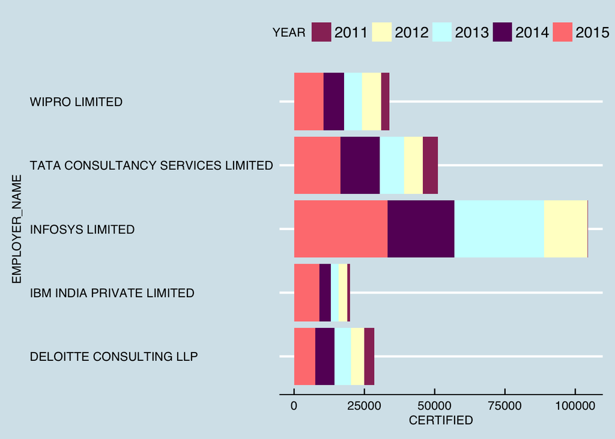

```r
g <- ggplot(company_df, aes(x=EMPLOYER_NAME, y = CERTIFIED))
g + geom_bar(stat = "identity", aes(fill = YEAR), position = "stack") + coord_flip() + theme_economist() + scale_fill_excel()
```

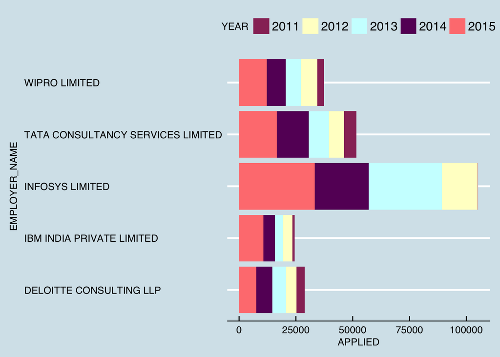

```r
g <- ggplot(company_df, aes(x=EMPLOYER_NAME, y = APPLIED))
g + geom_bar(stat = "identity", aes(fill = YEAR), position = "stack") + coord_flip() + theme_economist() + scale_fill_excel()
```

### DATA SCIENCE JOB ANALYSIS

Now, let’s look at how Data Scientist related Jobs have changed over the last 5 years!

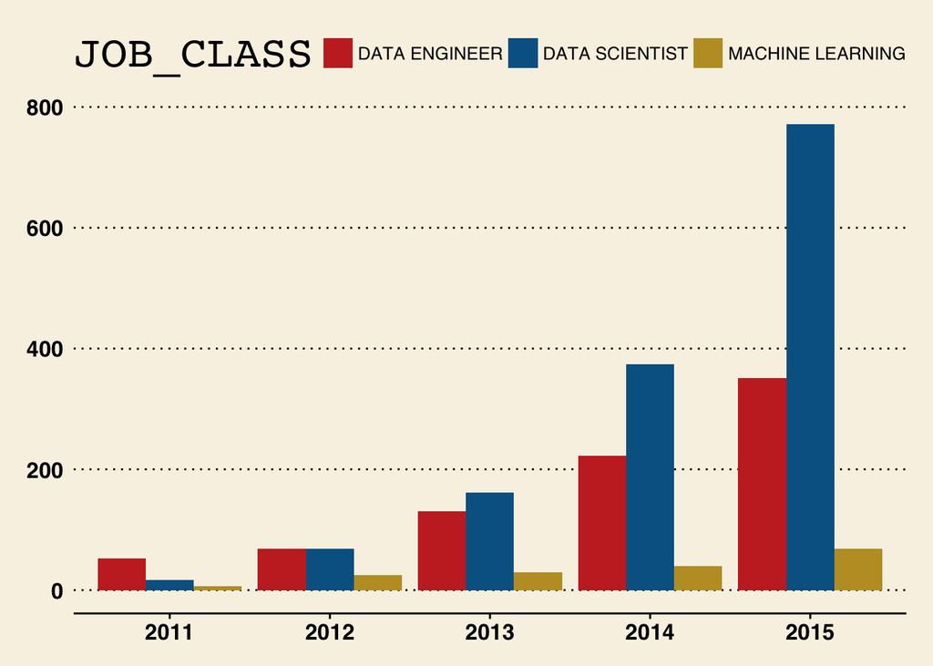

```r
datascience_df = h1b_df %>%
                 filter(JOB_CLASS != "OTHER" & JOB_CLASS != "DATA ANALYST") %>%
                 mutate(certified = ifelse(CASE_STATUS == "CERTIFIED",1,0)) %>%
                 group_by(JOB_CLASS, YEAR) %>%
                 summarise(APPLIED = n(), CERTIFIED = sum(certified))

g <- ggplot(datascience_df, aes(x=YEAR, y = CERTIFIED))
g + geom_bar(stat = "identity", aes(fill = JOB_CLASS), position = "dodge")  + theme_wsj() + scale_fill_wsj()
```

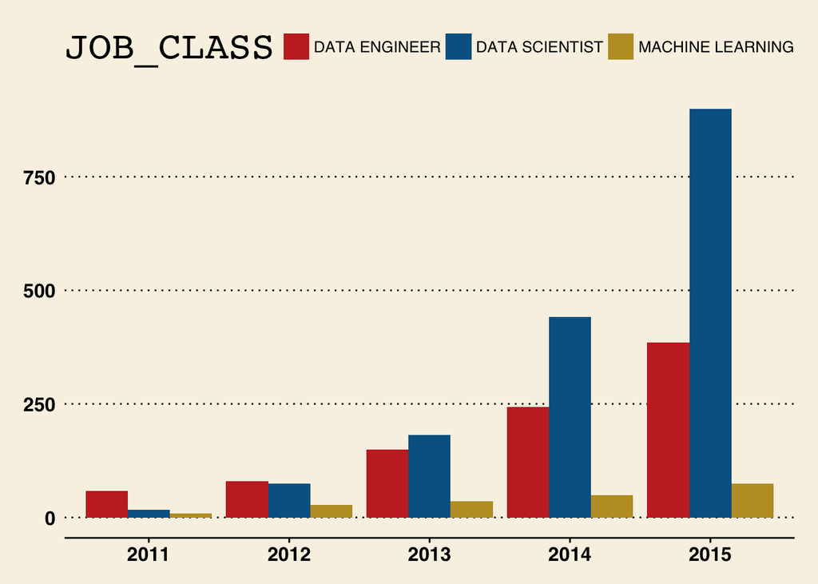

```r
g <- ggplot(datascience_df, aes(x=YEAR, y = APPLIED))
g + geom_bar(stat = "identity", aes(fill = JOB_CLASS), position = "dodge") + theme_wsj() + scale_fill_wsj()
```

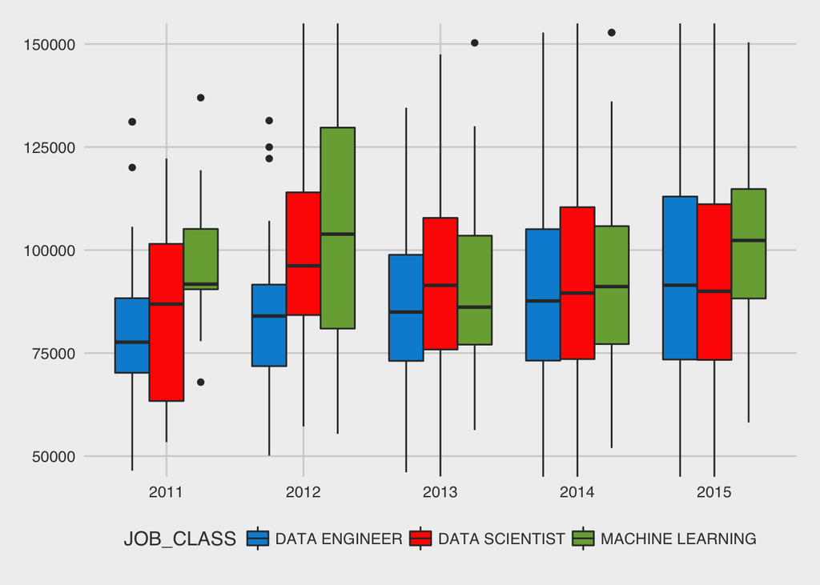

```r
datascience_df = h1b_df %>%
                 filter(JOB_CLASS != "OTHER" & JOB_CLASS != "DATA ANALYST") %>%
                 group_by(JOB_CLASS, YEAR)
#datascience_df <- datascience_df %>% filter(JOB_CLASS != "MACHINE LEARNING")

g <- ggplot(datascience_df, aes(x=YEAR, y = PREVAILING_WAGE))
g <- g + geom_boxplot(aes(fill = JOB_CLASS))
g + theme_fivethirtyeight() + scale_fill_fivethirtyeight()+ coord_cartesian(ylim = c(50000,150000))
```

### SENIORITY ANALYSIS

Next, let’s analyze the seniority among the different Data Scientist Positions

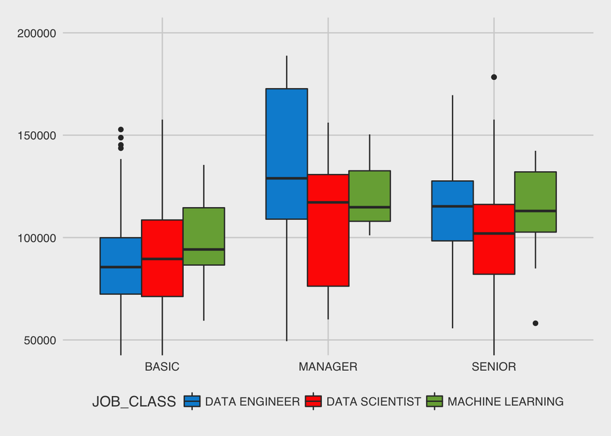

```r
datascience_df = h1b_df %>%
                 filter(JOB_CLASS != "OTHER" & JOB_CLASS != "DATA ANALYST" & YEAR == '2015') %>%
                 group_by(JOB_LEVEL, YEAR)
#datascience_df <- datascience_df %>% filter(JOB_CLASS != "MACHINE LEARNING")

g <- ggplot(datascience_df, aes(x=JOB_LEVEL, y = PREVAILING_WAGE))
g <- g + geom_boxplot(aes(fill = JOB_CLASS))
g + theme_fivethirtyeight() + scale_fill_fivethirtyeight()+ coord_cartesian(ylim = c(50000,200000))
```

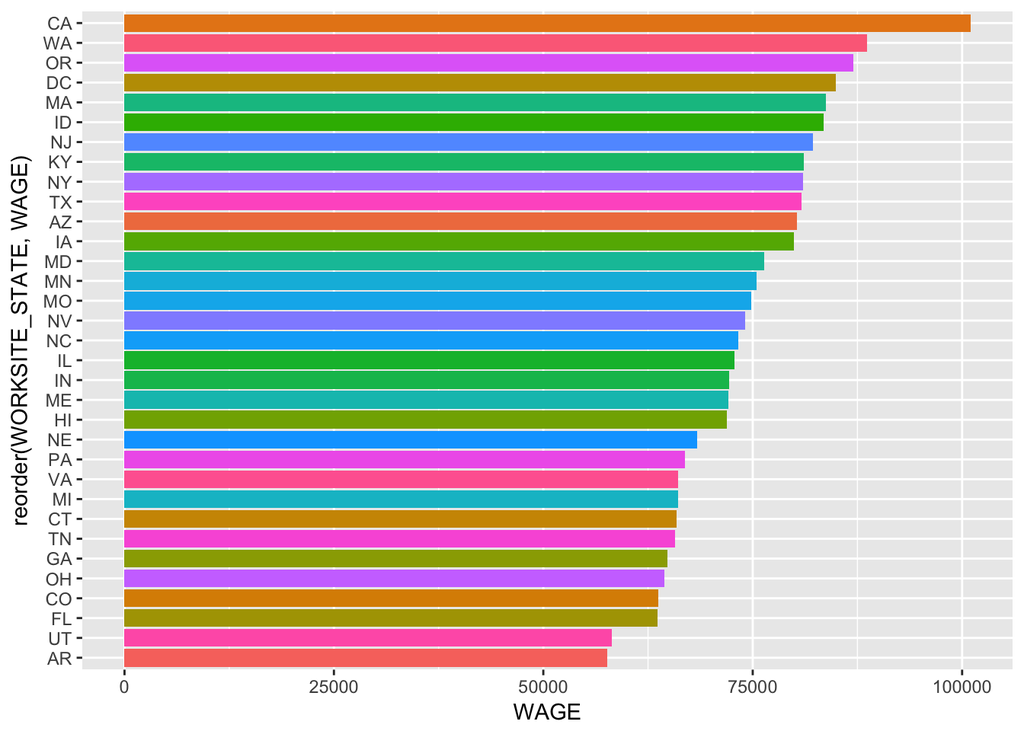

```r
ds_state_df <- h1b_df %>%
               filter(JOB_CLASS != "OTHER" & JOB_CLASS != "DATA ANALYST" & YEAR == '2015' & JOB_LEVEL == 'BASIC') %>%
               group_by(WORKSITE_STATE) %>%
               summarise(WAGE = mean(PREVAILING_WAGE), N_JOBS = n()) %>%
               mutate(WAGE_SCALED = 0.001*WAGE) %>%
               arrange(desc(WAGE))


dimm = dim(ds_state_df)[1]

g <- ggplot(ds_state_df, aes(x=reorder(WORKSITE_STATE,WAGE), y = WAGE))
g <- g + geom_bar(stat="identity", aes(fill= WORKSITE_STATE))
g <- g  + scale_colour_discrete() + coord_flip() + guides(fill=FALSE)
g
```

As you observe there is a big variation across the states! Next, we will explore mapping the Wage metric onto a geographical map. First, we need to convert our abbreviated State code to full State names in lower case in order to use the fiftystater package.

```r
 #'x' is the column of a data.frame that holds 2 digit state codes
stateFromLower <-function(x) {
   #read 52 state codes into local variable [includes DC (Washington D.C. and PR (Puerto Rico)]
  st.codes<-data.frame(
                      state=as.factor(c("AK", "AL", "AR", "AZ", "CA", "CO", "CT", "DC", "DE", "FL", "GA",
                                         "HI", "IA", "ID", "IL", "IN", "KS", "KY", "LA", "MA", "MD", "ME",
                                         "MI", "MN", "MO", "MS",  "MT", "NC", "ND", "NE", "NH", "NJ", "NM",
                                         "NV", "NY", "OH", "OK", "OR", "PA", "PR", "RI", "SC", "SD", "TN",
                                         "TX", "UT", "VA", "VT", "WA", "WI", "WV", "WY")),
                      full=as.factor(c("alaska","alabama","arkansas","arizona","california","colorado",
                                       "connecticut","district of columbia","delaware","florida","georgia",
                                       "hawaii","iowa","idaho","illinois","indiana","kansas","kentucky",
                                       "louisiana","massachusetts","maryland","maine","michigan","minnesota",
                                       "missouri","mississippi","montana","north carolina","north dakota",
                                       "nebraska","new hampshire","new jersey","new mexico","nevada",
                                       "new york","ohio","oklahoma","oregon","pennsylvania","puerto rico",
                                       "rhode island","south carolina","south dakota","tennessee","texas",
                                       "utah","virginia","vermont","washington","wisconsin",
                                       "west virginia","wyoming"))
                       )
     #create an nx1 data.frame of state codes from source column
  st.x<-data.frame(state=x)
     #match source codes with codes from 'st.codes' local variable and use to return the full state name
  refac.x<-st.codes$full[match(st.x$state,st.codes$state)]
     #return the full state names in the same order in which they appeared in the original source
  return(refac.x)

}

ds_state_df$WORKSITE_STATE_FULL <- stateFromLower(ds_state_df$WORKSITE_STATE)
```

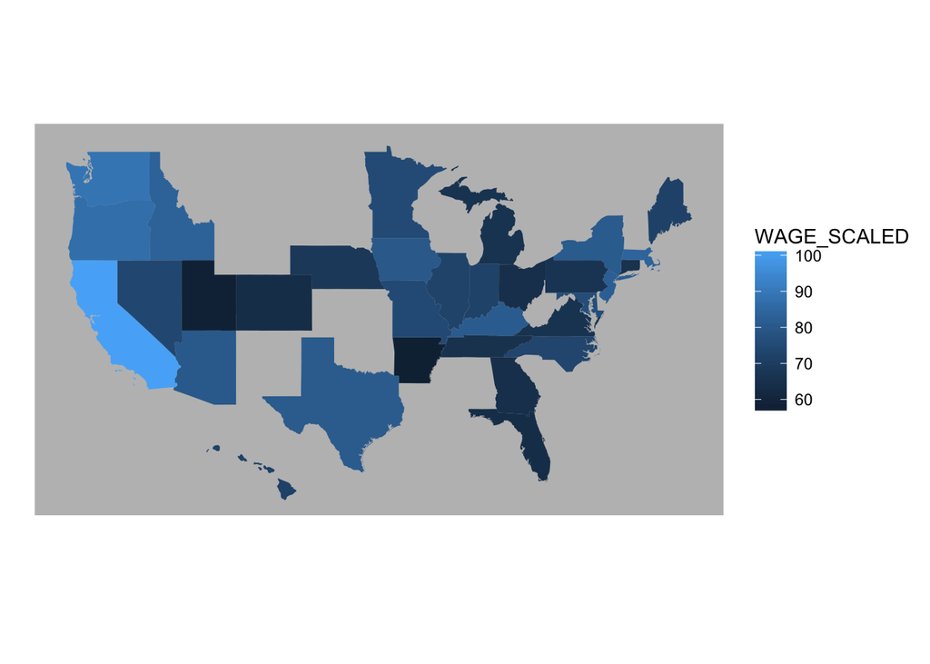

```r
library(fiftystater)
library(colorplaner)

p <- ggplot(ds_state_df, aes(map_id = WORKSITE_STATE_FULL)) +
  # map points to the fifty_states shape data
  geom_map(aes(fill = WAGE_SCALED), map = fifty_states) +
  expand_limits(x = fifty_states$long, y = fifty_states$lat) +
  coord_map() +
  scale_x_continuous(breaks = NULL) +
  scale_y_continuous(breaks = NULL) +
  labs(x = "", y = "") +
  theme(legend.position = "bottom",
        panel.background = element_rect(fill="grey"))

p + theme(legend.position = "right") + scale_colour_brewer(palette = "OrRd")
```

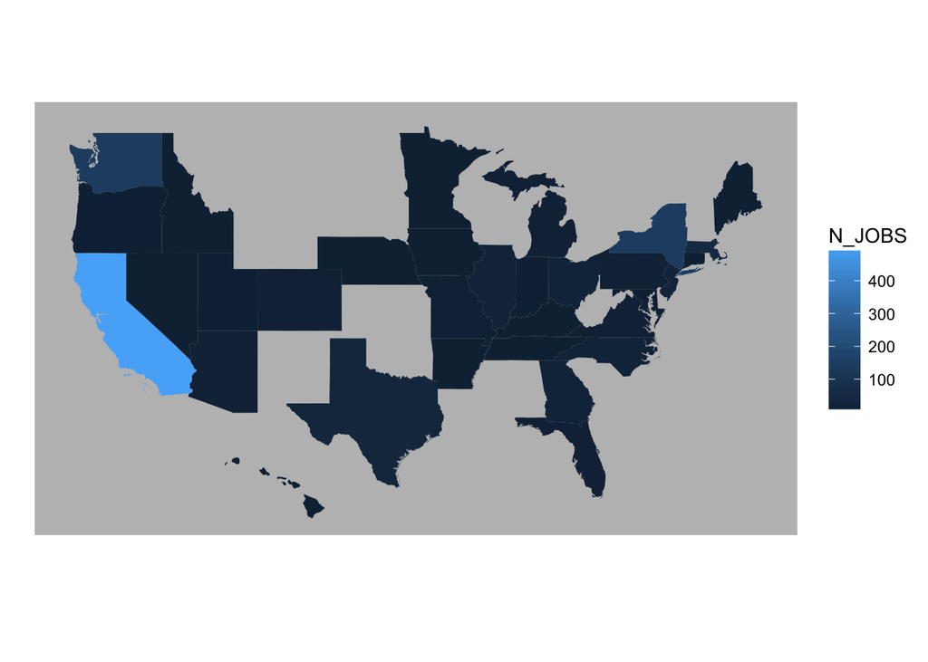

```r
p <- ggplot(ds_state_df, aes(map_id = WORKSITE_STATE_FULL)) +
  # map points to the fifty_states shape data
  geom_map(aes(fill = N_JOBS), map = fifty_states) +
  expand_limits(x = fifty_states$long, y = fifty_states$lat) +
  coord_map() +
  scale_x_continuous(breaks = NULL) +
  scale_y_continuous(breaks = NULL) +
  labs(x = "", y = "") +
  theme(legend.position = "bottom",
        panel.background = element_rect(fill="grey"))

p + theme(legend.position = "right")
```

```r
library(ggmap)

h1b_df$WORKSITE_STATE_FULL <- stateFromLower(h1b_df$WORKSITE_STATE)

ds_city_df <- h1b_df %>%
                 filter(JOB_CLASS != "OTHER" & JOB_CLASS != "DATA ANALYST" & YEAR == '2015' & JOB_LEVEL == 'BASIC') %>%
                 group_by(WORKSITE_CITY, WORKSITE_STATE_FULL) %>%
                 summarise(WAGE = mean(PREVAILING_WAGE), N_JOBS = n()) %>%
                 mutate(WAGE_SCALED = 0.001*WAGE) %>%
                 arrange(desc(WAGE))
```

Adding Geocode location this dataframe.

```r
cities_list = ds_city_df %>% select(WORKSITE_CITY) %>% sapply(function(x) unique(x))
cities_list = cbind(geocode(as.character(cities_list)),cities_list)
```

```r
ds_city_df = full_join(ds_city_df,cities_list,by="WORKSITE_CITY")

head(ds_city_df)
```

```
## Source: local data frame [6 x 7]
## Groups: WORKSITE_CITY [6]
##
##       WORKSITE_CITY WORKSITE_STATE_FULL     WAGE N_JOBS WAGE_SCALED
##               <chr>              <fctr>    <dbl>  <int>       <dbl>
## 1         CHARLOTTE      north carolina 120515.2      1    120.5152
## 2         CUPERTINO          california 119138.0      5    119.1380
## 3 SAN FRANCISCO, CA          california 118061.0      1    118.0610
## 4            TACOMA          washington 114795.0      1    114.7950
## 5          PORTLAND              oregon 114754.0      1    114.7540
## 6     SAN FRANCSICO          california 114400.0      1    114.4000
## # ... with 2 more variables: lon <dbl>, lat <dbl>
```

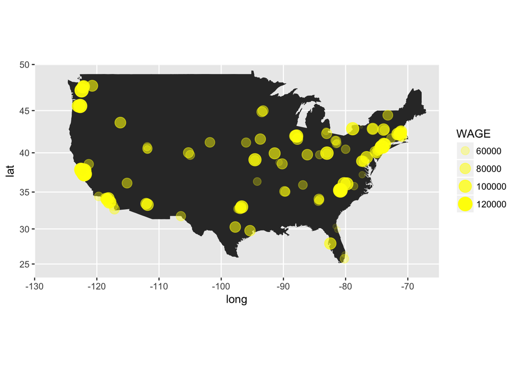

```r
USA = map_data(map="usa")

g <- ggplot(USA, aes(x=long, y=lat)) +
     geom_polygon() +
     geom_point(data=ds_city_df, aes(x=lon, y=lat, alpha=WAGE, size = WAGE), color="yellow") +
     coord_map(xlim = c(-130,-65),ylim=c(23,50))
g
```

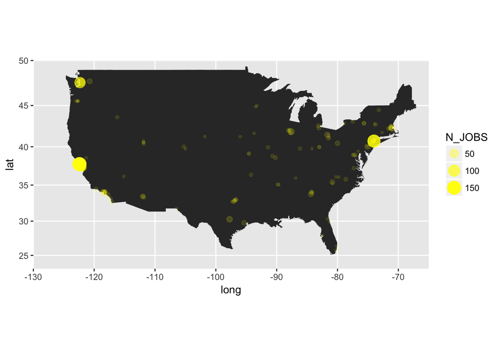

```r
g <- ggplot(USA, aes(x=long, y=lat)) +
     geom_polygon() +
     geom_point(data=ds_city_df, aes(x=lon, y=lat, size=N_JOBS, alpha=N_JOBS),color = "yellow") +
     coord_map(xlim = c(-130,-65),ylim=c(23,50))
g
```

We can zoom into the California data as it has the most number of Data Science jobs and among the highest salaries.

```r
CA <- map_data("state",region="california")
cali_df = ds_city_df %>%
          filter(WORKSITE_STATE_FULL == "california") %>%
          arrange(desc(N_JOBS))

head(cali_df)
```

```
## Source: local data frame [6 x 7]
## Groups: WORKSITE_CITY [6]
##
##   WORKSITE_CITY WORKSITE_STATE_FULL     WAGE N_JOBS WAGE_SCALED       lon
##           <chr>              <fctr>    <dbl>  <int>       <dbl>     <dbl>
## 1 SAN FRANCISCO          california 102399.1    153    102.3991 -122.4194
## 2    MENLO PARK          california 112876.4     55    112.8764 -122.1817
## 3     PALO ALTO          california 108252.2     43    108.2522 -122.1430
## 4 MOUNTAIN VIEW          california 100528.4     42    100.5284 -122.0839
## 5      SAN JOSE          california 108486.0     32    108.4860 -121.8863
## 6     SUNNYVALE          california 109569.6     31    109.5696 -122.0363
## # ... with 1 more variables: lat <dbl>
```

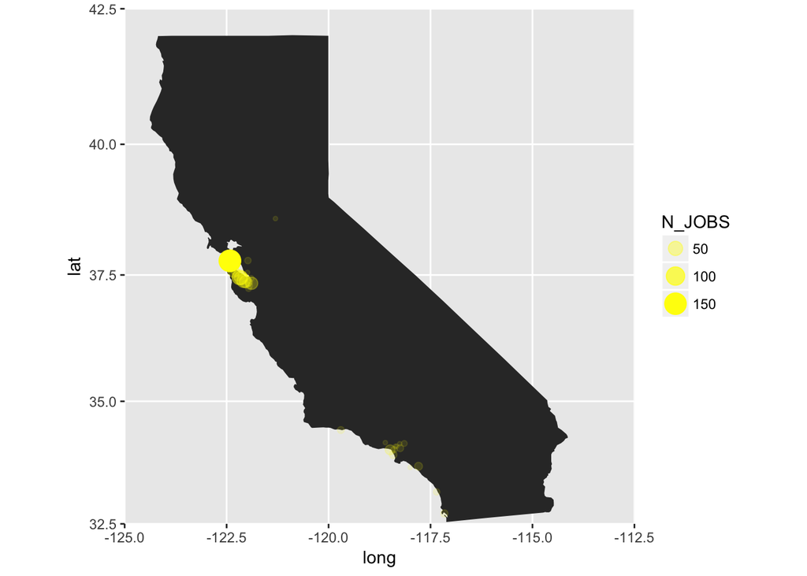

```r
library(ggrepel)

g <- ggplot(CA, aes(x=long, y=lat)) +
     geom_polygon() +
     geom_point(data=cali_df, aes(x=lon, y=lat, size=N_JOBS, alpha=N_JOBS),color = "yellow") +
     coord_map(xlim = c(-125,-112.5),ylim=c(32.5,42.5))

g
```

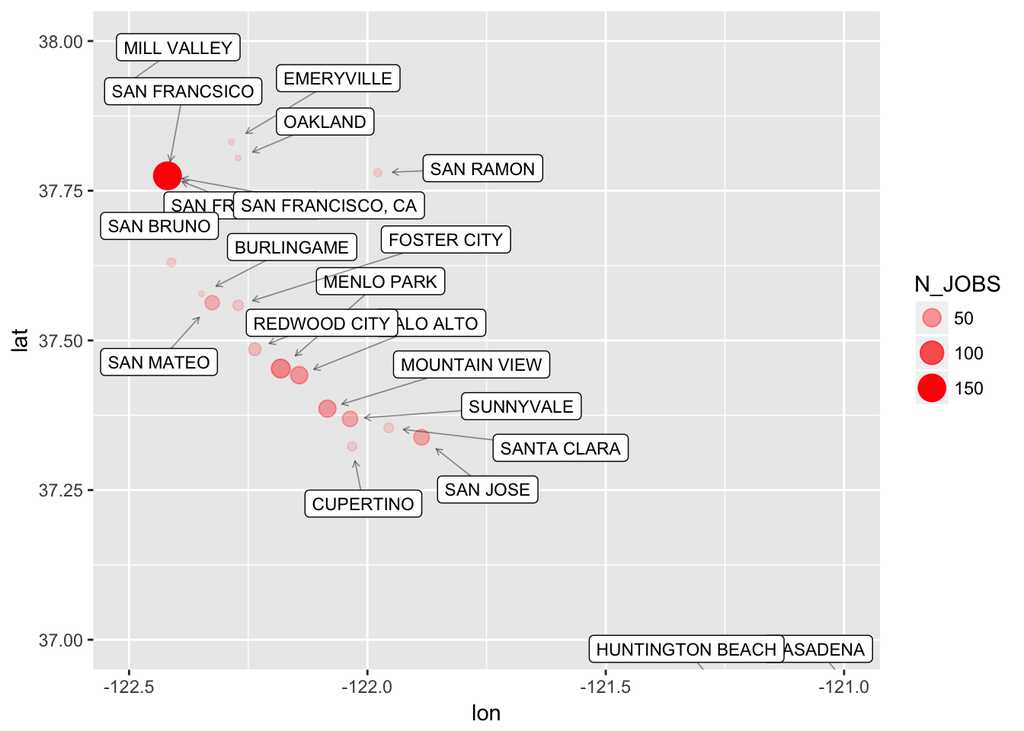

```r
cali_top_df = cali_df %>% filter(WAGE_SCALED > 90)

#g <- ggplot(CA, aes(x=long, y=lat)) +
#     geom_polygon()
g <- ggplot(data=cali_top_df, aes(x=lon, y=lat)) + geom_point(aes(size=N_JOBS,alpha = N_JOBS), color="red") +
     coord_cartesian(xlim = c(-122.5,-121),ylim=c(37,38)) +
     geom_label_repel(aes(label = WORKSITE_CITY), size = 3, nudge_x = 0.05, color = "black",segment.color = "#333333", segment.alpha = 0.5, segment.size = 0.3, arrow = arrow(length = unit(0.01, 'npc')), point.padding = unit(1, 'lines'), force = 0.25)

g
```

### Cost of Living Analysis

```r
library(dplyr)
coli_data = read.csv("data/coli_data.csv")

coli_data %>% dplyr::select(city,coli)
```

```
##                 city   coli
## 1           New York 100.00
## 2           Honolulu  84.02
## 3      San Francisco 111.09
## 4          Anchorage  72.17
## 5         Washington  87.15
## 6          New Haven  71.27
## 7           Berkeley  84.03
## 8         Santa Cruz  80.07
## 9           Brooklyn  84.32
## 10           Seattle  77.23
## 11            Boston  83.17
## 12           Oakland  83.82
## 13             Miami  75.64
## 14        Charleston  68.67
```

[output cut: 100 more lines]